# Лабораторная работа №6

Решение моделей в непрерывном и дискретном времени

Ко Антон Геннадьевич

antonkosakh@gmail.com

Российский университет дружбы народов

2026-11-21

# Информация

## Докладчик

- Ко Антон Геннадьевич
- студент
- Российский университет дружбы народов им. П. Лумумбы
- 1132221551@rudn.ru
- https://SenDerMen04.github.io/ru/

## 2. Выполнение лабораторной работы

Численное решение в Julia будет иметь следующий вид, а также график, соответствующий полученному решению (рис. #fig:001):

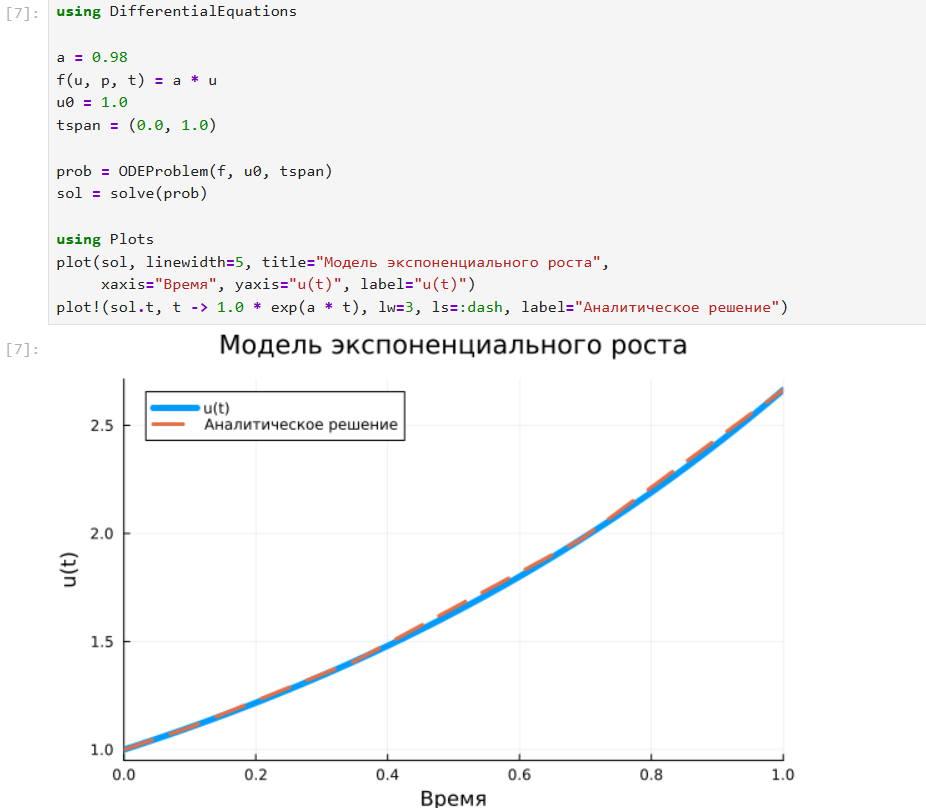

График модели экспоненциального роста

Если требуется задать точность решения, то можно воспользоваться параметрами `abstol` (задаёт близость к нулю) и `reltol` (задаёт относительную точность). По умолчанию эти параметры имеют значение `abstol = 1e-6` и `reltol = 1e-3`.

Для модели экспоненциального роста (рис. #fig:002):

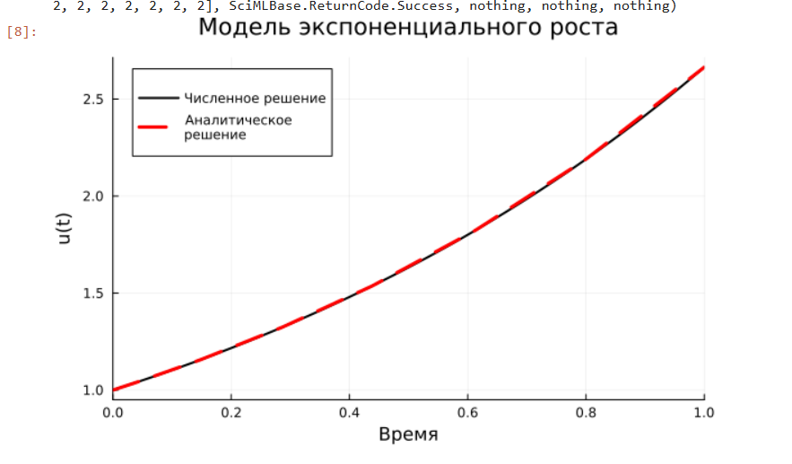

График модели экспоненциального роста (задана точность решения)

### 2.3. Система Лоренца

Решение системы неустойчиво на аттракторе, что не позволяет применять классические численные методы на больших отрезках времени, требуется использовать высокоточные вычисления.

Численное решение в Julia будет иметь следующий вид (рис. #fig:003):

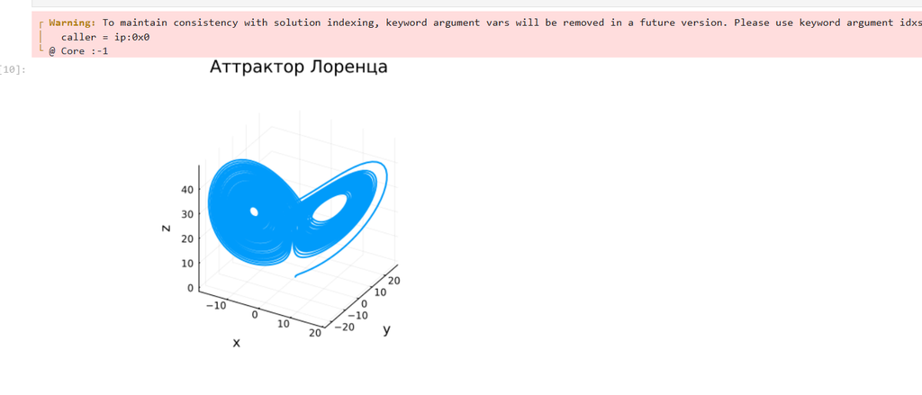

Аттрактор Лоренца

Можно отключить интерполяцию (рис. #fig:004):

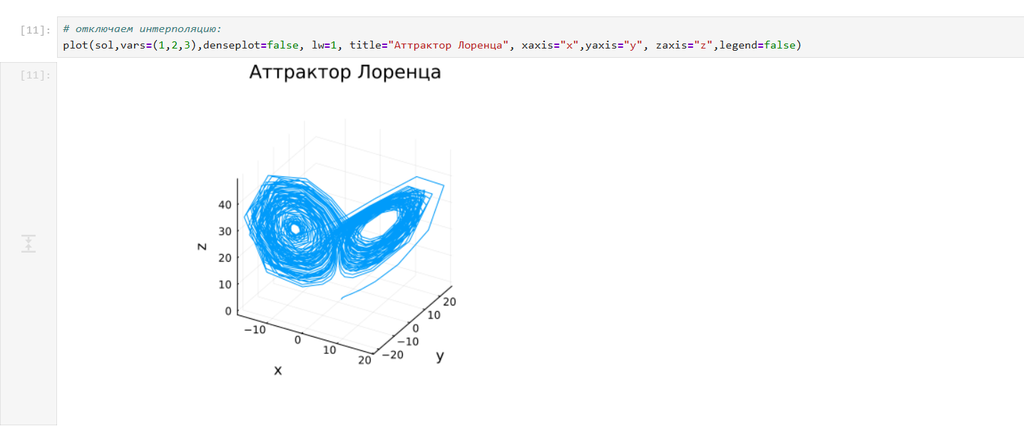

Аттрактор Лоренца (интерполяция отключена)

### 2.4. Модель Лотки–Вольтерры

Модель Лотки–Вольтерры описывает взаимодействие двух видов типа «хищник – жертва».

Численное решение в Julia будет иметь следующий вид (рис. #fig:005):

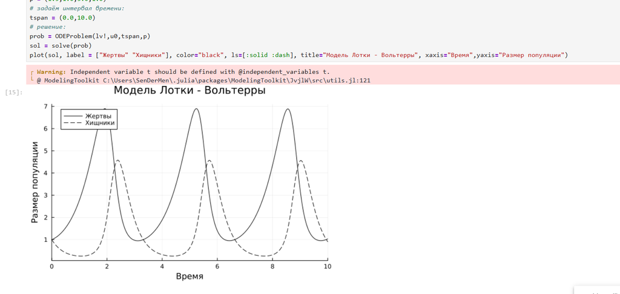

Модель Лотки–Вольтерры: динамика изменения численности популяций

Фазовый портрет (рис. #fig:006):

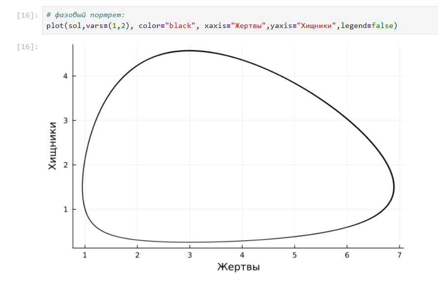

Модель Лотки–Вольтерры: фазовый портрет

### 2.5. Самостоятельное выполнение

Выполнение задания №1 (рис. #fig:007):

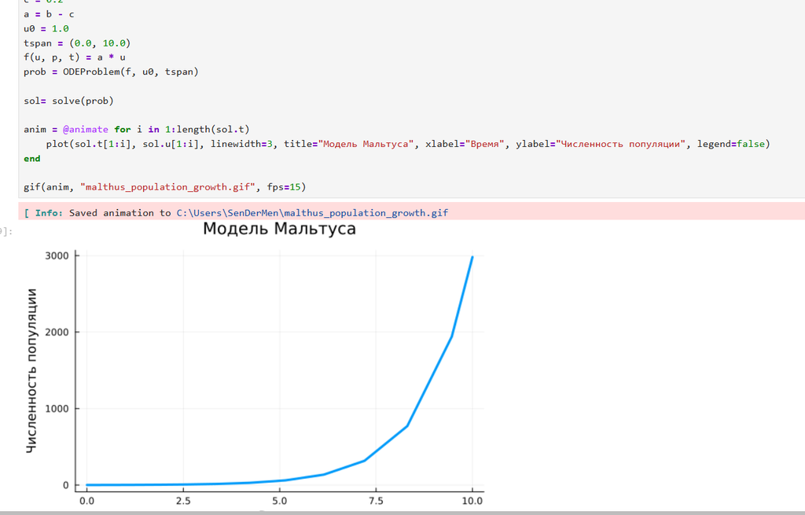

Решение задания №1

Выполнение задания №2 (рис. #fig:008):

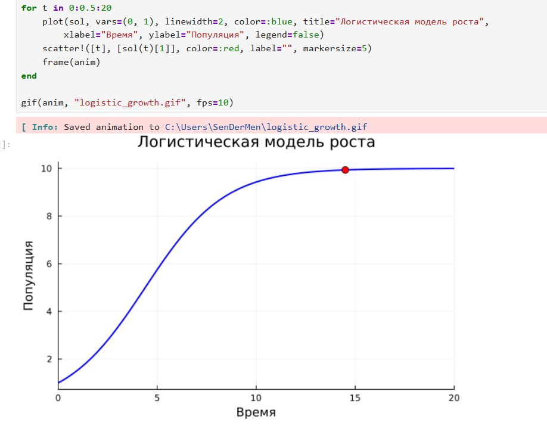

Решение задания №2

Выполнение задания №3 (рис. #fig:009):

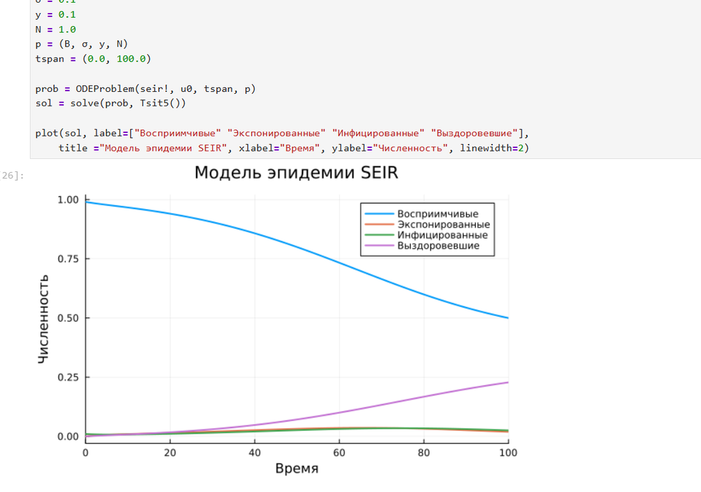

Выполнение задания №5 (рис. #fig:011):

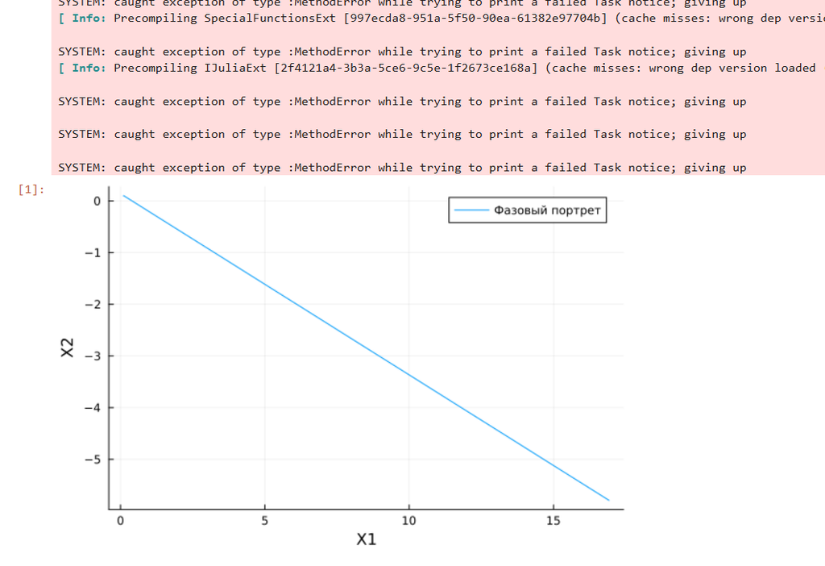

Решение задания №5

Выполнение задания №6 (рис. #fig:012):

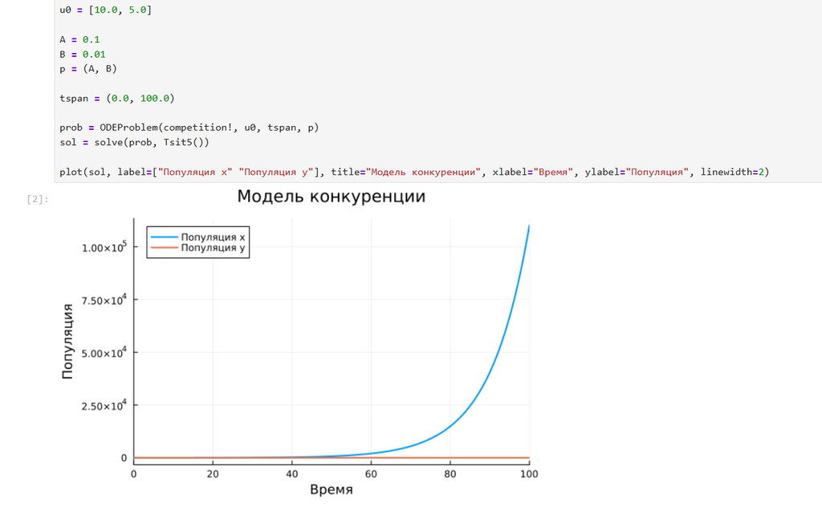

Решение задания №6

Выполнение задания №7 (рис. #fig:013):

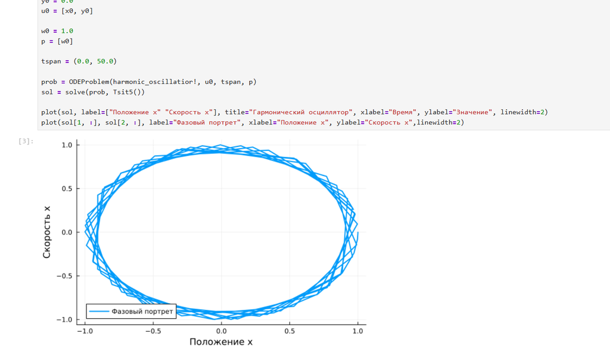

Решение задания №7

Выполнение задания №8 (рис. #fig:014):

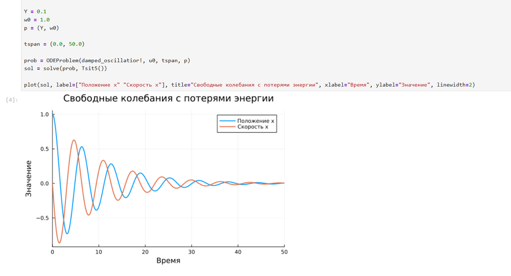

Решение задания №8

## 3. Вывод

В ходе выполнения лабораторной работы были освоены специализированные пакеты для решения задач в непрерывном и дискретном времени.